# 多元线性回归

shixiangzhou

2015年10月6日

# 多元线性回归分析

回归分析研究的主要对象时客观事物变量间的统计关系，它是建立在对客观事物进行大量实验和观察基础上，用来寻找隐藏在看起来不确定的现象中的统计规律的统计方法。。

与相关分析的主要区别是：一是回归分析中，解释变量称为自变量，被解释变量称为因变量；而相关分析中，并不区分自变量和因变量，各变量处于平等地位。而是在相关分析中所涉及的变量全是随机变量；而回归分析中因变量是随机变量，而自变量不一定。三是相关分析研究主要是为刻画两类变量之间的线性相关程度。而回归分析不仅可以揭示自变量对因变量的影响大小，还可以用回归方程进行预测和控制。

## 多元线性回归模型的建立

1978-2008年我国财政收入和国民生产总值，税收，进出口贸易总额，经济活动人口之间的依赖关系，就需要建立多元回归模型。

$$\hat{y}=b_0+b_1x_1+b_2x_2+\cdots+b_px_p$$

$b_i(i=1,2,\cdots,p)$称为偏回归系数，当其他自变量对因变量的线性影响固定时，$b_i$反映了第$i$个自变量$x_i$对因变量$y$线性影响的大小。

### 多元线性回归模型的一般形式

随机变量$y$与一般变量$x$的线性回归模型为：

$$y=\beta_0+\beta_1x_1+\beta_2x_2+\cdots+\beta_px_p+\epsilon$$

当我们得到n组观测数据$( x_1,x_2,\cdots,x_p,y_i)$时，$i=1,2,\cdots,n$，线性回归模型可表示为：

$$\begin{equation}
\begin{aligned}
y_1 & =\beta_0+\beta_1x_{11}+\beta_2x_{12}+\cdots+\beta_px_{1p}+\epsilon_1\\
y_2 & =\beta_0+\beta_1x_{21}+\beta_2x_{22}+\cdots+\beta_px_{2p}+\epsilon_2\\
\cdots &\cdots \\
y_n & =\beta_0+\beta_1x_{n1}+\beta_2x_{n2}+\cdots+\beta_px_{np}+\epsilon_n
\end{aligned}\end{equation}$$

将其写为矩阵形式$y=X\beta+\epsilon$,其中

$$y=\begin{bmatrix}y_1\\y_2\\ \cdots \\y_n
\end{bmatrix}$$

$$X=\begin{bmatrix}1 & x_{11} & x_{12} &\cdots & x_{1p} \\
1 & x_{11} & x_{12} &\cdots & x_{1p} \\
\cdots & \cdots & \cdots &\cdots & \cdots\\
1 & x_{n1} & x_{n2} &\cdots & x_{np} \\
\end{bmatrix}$$
$$\beta=\begin{bmatrix}\beta_0\\ \beta_1 \\ \cdots \\ \beta_p
\end{bmatrix}$$
$$\epsilon=\begin{bmatrix}\epsilon_1\\ \epsilon_2 \\ \cdots \\ \epsilon_n
\end{bmatrix}$$

通常称$X$为设计阵，$\beta$为回归系数向量。

线性回归模型的基本假设

1. 解释变量一般来说是非随机变量。
2. 误差等方差及不相关假定(G-M条件)：
3. 误差正态分布的假定条件为：$\epsilon_i \verb"~"N(0,\sigma^2)(i=1,2,\cdots,n)$
4. $n>p$，即要求样本容量个数多于解释变量的个数。

### 多元回归参数的最小二乘估计

由多元模型的矩阵形式可知，若模型的参数$\beta$的估计量$\hat{\beta}$已获得，则$\hat{y}=X\hat{\beta}$，于是残差$\epsilon_i=y_i-\hat{y_i}$，根据最小二乘原理，所选择的估计方法应使得估计量$\hat{y_i}$与观察值$y_i$之间残差$\epsilon_i$在所有样本点上达到最小。

即，

$$Q=\sum_{i=1}^n (y_i-\hat{y_i})^2=\epsilon^{'}\epsilon=(y-X\hat{\beta})^{'} (y-X\hat{\beta})$$
根据微积分求极值原理，$Q$对$\hat{\beta}$求导且等于0，可求得使$Q$达到最小的$\hat{\beta}$，这就是所谓的最小二乘(LS)法。

$$\hat{\beta_{LS}}=(X^{'} X)^{-1} X^{'}y$$

另外，可证明，在正态性假定下，回归系数$\beta$的LS估计与极大似然(ML)估计完全相同，即$\hat{\beta_{ML}}=\hat{\beta_{LS}}$，关于回归系数的极大似然估计参见有关文献。

**例题1** 财政收入的多元回归分析

《中国统计年鉴》及海关总署，数据时限为1978-2008年，其中$t$为年份，$y$为财政收入(百亿元)，$x_1$为国内生产总值(百亿元)，$x_2$税收，$x_3$为进出口贸易总额，$x_4$经济活动人口(百万人)

```r
yX=read.table("clipboard",header=T)#加载mvstat.xls$4.4数据
head(yX)
```

```
##         y     x1     x2     x3     x4
## 1 11.3262 36.241 5.1928  3.550 406.82
## 2 11.4638 40.382 5.3782  4.120 415.92
## 3 11.5993 45.178 5.7170  5.700 429.03
## 4 11.7579 48.603 6.2989  8.904 441.65
## 5 12.1233 53.018 7.0002 12.801 456.74
## 6 18.6695 59.574 7.5559 15.903 467.07
```

```r
(fm=lm(y~x1+x2+x3+x4,data=yX))#显示多元线性回归模型
```

```
##
## Call:
## lm(formula = y ~ x1 + x2 + x3 + x4, data = yX)
##
## Coefficients:
## (Intercept)           x1           x2           x3           x4
##  23.5321088   -0.0033866    1.1641150    0.0002919   -0.0437416
```

### 标准化偏回归系数

由于自变量$x_j(j=1,2,\cdots,p)$与因变量都是有单位的，从数值上看它们样本取值的极差会有很大的差异，均数与标准差也各不相同，所以不能由偏回归系数的大小直接说明对因变量线性影响的大小。这个问题可以通过变量标准化与计算标准化偏回归的方法处理。

对每一个变量标准化后，再计算方程的偏回归系数，可得标准化偏回归系数，常用$\hat{\beta _i}^{*}=\hat{\beta_i}\frac{s_i}{s_y}(i=1,2,\cdots,p)$ 式中，$s_i$与$s_y$分别是各自变量和因变量的标准差。

```r
library(mvstats)
coef.sd(fm)#标准化偏回归系数结果
```

```
## $coef.sd
##            x1            x2            x3            x4
## -0.0174513678  1.0423522972  0.0009628564 -0.0371053994
```

## 多元线性回归模型检验

### 对多元回归方程做假设检验也可以用方差分析

因变量$y$的离差平方和经回归分析后被分解为两个部分。
$$SS_T=\sum_{i=1}^n(y_i-\bar{y})^2=\sum_{i=1}^n(y_i-\hat{y})^2+\sum_{i=1}^n(\hat{y_i}-\bar{y})^2=SS_R+SS_E$$

这与单变量回归是一样的，同时自由度也被分解为俩个部分。其中，回归自由度就是自变量的个数。
$$df_R=p,df_E=df_T-df_R=(n-1)-p=n-p-1$$

由此可以分别计算两部分的均方：

$$MS_R=\frac{SS_R}{df_R}=\sum_{i=1}^n(\hat{y_i}-\bar{y})^2/p$$

$$MS_E=\frac{SS_E}{df_E}$$

方差分析的假设检验是

$$H_0:\beta_1=\beta_2=\cdots=\beta_p=0$$

意味着因变量$y$与所有的自变量$x_i$都不存在回归关系，多元回归方程没有意义。

相应的备择假设$H_1:\beta_1,\beta_2,\cdots,\beta_p$不全为0，$H_0$成立。

$$F=\frac{MS_R}{MS_E}\verb"~"F(p,n-p-1)$$

### 回归系数的假设检验

多元回归方程有统计学意义，并不能说明每一个偏回归系数都有意义，所以有必要对每一个偏回归系数做假设检验。在$\beta_j=0$时，偏回归系数$\hat{\beta_j}(j=1,2,\cdots,p)$服从正态分布，所以可以用t检验法对回归系数做检验。

假设检验： $H_{0j}:\beta_j=0,H_{1j}\ne 0$，原假设成立时$\hat{\beta}~N(\beta,\sigma^2(X^{'}X)^{-1})$,构造检验统计量：
$$t_j=\frac{\hat{\beta_j}-\beta_j}{s_{\hat{\beta_j}}}(j=1,2,\cdots,p)$$

式中$s_{\hat{\beta_j}}$是第j个偏回归系数的标准误差，其计算比较复杂。 当原假设成立时，上面的$t$服从自由度为$n-p-1$的t分布。

```r
anova(fm)#多元线性回归模型方差分析
```

```
## Analysis of Variance Table
##
## Response: y
##           Df Sum Sq Mean Sq    F value    Pr(>F)
## x1         1 694627  694627 89259.0016 < 2.2e-16 ***
## x2         1  17803   17803  2287.6286 < 2.2e-16 ***
## x3         1     24      24     3.0569    0.0922 .
## x4         1    174     174    22.2954 7.005e-05 ***
## Residuals 26    202       8
## ---
## Signif. codes:  0 '***' 0.001 '**' 0.01 '*' 0.05 '.' 0.1 ' ' 1
```

回归系数的t检验代码：

```r
summary(fm)#多元线性回归系数t检验
```

```
##
## Call:
## lm(formula = y ~ x1 + x2 + x3 + x4, data = yX)
##
## Residuals:
##     Min      1Q  Median      3Q     Max
## -5.0229 -2.1354  0.3297  1.2639  6.9690
##
## Coefficients:
##               Estimate Std. Error t value Pr(>|t|)
## (Intercept) 23.5321088  4.5990714   5.117 2.47e-05 ***
## x1          -0.0033866  0.0080749  -0.419    0.678
## x2           1.1641150  0.0404889  28.751  < 2e-16 ***
## x3           0.0002919  0.0085527   0.034    0.973
## x4          -0.0437416  0.0092638  -4.722 7.00e-05 ***
## ---
## Signif. codes:  0 '***' 0.001 '**' 0.01 '*' 0.05 '.' 0.1 ' ' 1
##
## Residual standard error: 2.79 on 26 degrees of freedom
## Multiple R-squared:  0.9997, Adjusted R-squared:  0.9997
## F-statistic: 2.289e+04 on 4 and 26 DF,  p-value: < 2.2e-16
```

由方差分析的结果可知，模型的P<0.0001，故本例回归模型有意义。由t检验结果可知，偏回归系数$b_2，b_4$的P值都小于0.01，可认为解释变量税收$x_2$和经济活动人口$x_4$显著，$b_1，b_3$的P值大于0.50，不能否定对$\beta_1=0，\beta_3=0$的假设，可以认为国内生产总值$x_1$和进出口贸易$x_3$对财政收入$y$没有显著的影响。

可以看到，国内生产总值，经济活动人口所对应的偏回归系数为负，这与经济现实不符。出现这种结果的原因可能是这些解释变量之间存在高度的共线性。

# 多元线性相关分析

当涉及的变量为三个或以上时，称为偏相关或复相关。

如果我们只想了解两个变量之间有无线性相关关系，并不需要建立它们之间的回归模型，也不需要区分自变量和因变量，这时可以用较为方便的相关分析方法。

$r_{ij}$任意两个变量之间的简单相关系数为：

$$r_{ij}=\frac{\sum_{ij}(x_i-\bar{x})(y_j-\bar{y})}{\sqrt{\sum_i(x_i-\bar{x})^2\sum_j(y_j-\bar{y})^2}}$$

**例题3** 财政收入与其他变量间的相关分析

计算变量两两间的相关系数。

```r
cor(yX)#多元数据相关系数矩阵
```

```
##            y        x1        x2        x3        x4
## y  1.0000000 0.9871498 0.9994718 0.9912053 0.6956619
## x1 0.9871498 1.0000000 0.9907018 0.9867664 0.7818066
## x2 0.9994718 0.9907018 1.0000000 0.9917094 0.7154297
## x3 0.9912053 0.9867664 0.9917094 1.0000000 0.7073820
## x4 0.6956619 0.7818066 0.7154297 0.7073820 1.0000000
```

给出变量两两间的矩阵散点图：

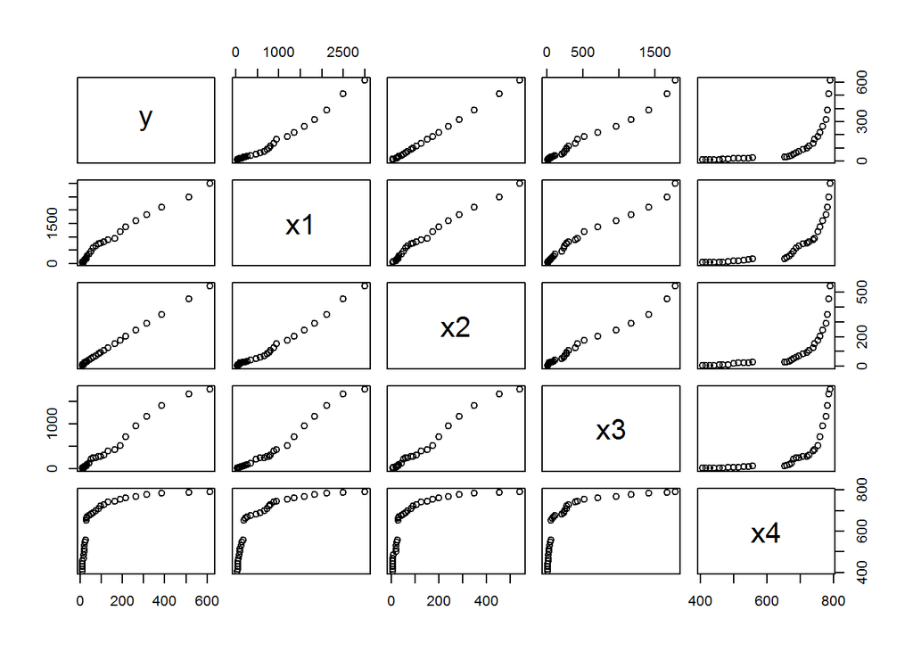

```r
pairs(yX)#多元数据散点图
```

计算相关系数矩阵的假设检验，计算相关系数的t值和P值。

```r
corr.test(yX)#多元数据相关系数检验
```

```
## corr test:
##          y     x1     x2    x3 x4
## y    0.000  0.000  0.000 0.000  0
## x1  33.267  0.000  0.000 0.000  0
## x2 165.614 39.214  0.000 0.000  0
## x3  40.336 32.772 41.560 0.000  0
## x4   5.215  6.752  5.514 5.389  0
## lower is t value，upper is p value
```

如有错误请联系 [e-mail]:shixiangbupt@qq.com.